# RADAR PLOT

JB

2017년 9월 5일

```
## [1] "C"
```

## 상대적 중요성으로 radar plot을 만들자!

다중회귀모형에서 여러 개의 설명변수가 있는 경우, 각 변수들의 상대적인 중요성을 평가하기 위한 방법은 모든 가능한 서브모형에 변수 하나를 추가하였을 때 R^2 값이 평균적 증감으로 알수 있다.

#### 필요 라이브러리 설치 및 데이터로드.

```
## Start:  AIC=304381
## SOLDPRICE ~ POSTDATE + GB + KRNAME + CONTRACT + GUARANTEE + CHANGES +
##     CONDITIONS + COMPONENT + reldate + relprice + genGap + DATEGAP +
##     PRICERATE
##
##
## Step:  AIC=304381
## SOLDPRICE ~ POSTDATE + GB + KRNAME + CONTRACT + GUARANTEE + CHANGES +
##     CONDITIONS + COMPONENT + reldate + relprice + genGap + PRICERATE
##
##
## Step:  AIC=304381
## SOLDPRICE ~ POSTDATE + GB + KRNAME + CONTRACT + GUARANTEE + CHANGES +
##     CONDITIONS + COMPONENT + relprice + genGap + PRICERATE
##
##              Df  Sum of Sq        RSS    AIC
## - CONTRACT    2 1.6222e+09 1.1862e+13 304379
## <none>                     1.1861e+13 304381
## - CHANGES     2 7.9055e+09 1.1868e+13 304387
## - relprice    1 1.4217e+10 1.1875e+13 304397
## - GUARANTEE   2 1.8676e+10 1.1879e+13 304400
## - COMPONENT   2 4.6202e+10 1.1907e+13 304435
## - POSTDATE    1 7.1172e+10 1.1932e+13 304468
## - CONDITIONS  4 2.0429e+11 1.2065e+13 304626
## - genGap      5 2.3975e+12 1.4258e+13 307104
## - GB          4 3.0534e+12 1.4914e+13 307774
## - KRNAME      8 1.2411e+13 2.4271e+13 314995
## - PRICERATE   1 4.3076e+14 4.4262e+14 358110
##
## Step:  AIC=304379
## SOLDPRICE ~ POSTDATE + GB + KRNAME + GUARANTEE + CHANGES + CONDITIONS +
##     COMPONENT + relprice + genGap + PRICERATE
##
##              Df  Sum of Sq        RSS    AIC
## <none>                     1.1862e+13 304379
## + CONTRACT    2 1.6222e+09 1.1861e+13 304381
## - CHANGES     2 6.7427e+09 1.1869e+13 304383
## - relprice    1 1.4182e+10 1.1876e+13 304395
## - GUARANTEE   2 1.8784e+10 1.1881e+13 304398
## - COMPONENT   2 4.5868e+10 1.1908e+13 304432
## - POSTDATE    1 7.9112e+10 1.1941e+13 304476
## - CONDITIONS  4 2.0449e+11 1.2067e+13 304625
## - genGap      5 2.3968e+12 1.4259e+13 307101
## - GB          4 3.0542e+12 1.4916e+13 307772
## - KRNAME      8 1.2418e+13 2.4281e+13 314997
## - PRICERATE   1 4.3148e+14 4.4334e+14 358131
```

### relweights(상대적 중요도)함수.

Robert I. Kabacoff의 R in action(2nd edition)책에 소개되어 있다.  
**중요!** 숫자가 아닌 설명변수는 relweights() 함수로 처리가 안되므로  
**숫자(as.numeric)형이나 범주(as.factor)형으로 변환** 해줘야 한다.

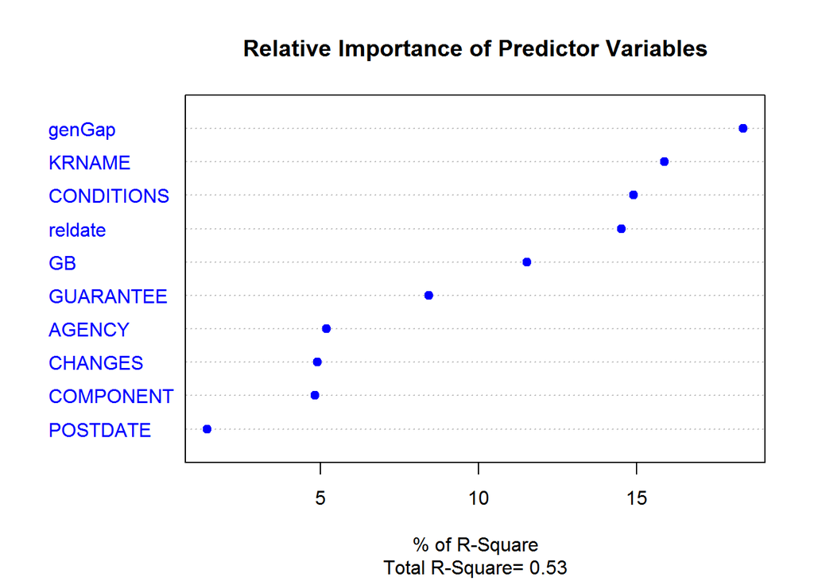

```r
relweights <- function(fit,...){
  R <- cor(fit$model)
  nvar <- ncol(R)
  rxx <- R[2:nvar, 2:nvar]
  rxy <- R[2:nvar, 1]
  svd <- eigen(rxx)
  evec <- svd$vectors
  ev <- svd$values
  delta <- diag(sqrt(ev))
  lambda <- evec %*% delta %*% t(evec)
  lambdasq <- lambda ^ 2
  beta <- solve(lambda) %*% rxy
  rsquare <- colSums(beta ^ 2)
  rawwgt <- lambdasq %*% beta ^ 2
  import <- (rawwgt / rsquare) * 100
  import <- as.data.frame(import)
  row.names(import) <- names(fit$model[2:nvar])
  names(import) <- "Weights"
  import <- import[order(import),1, drop=FALSE]
  dotchart(import$Weights, labels=row.names(import),
           xlab="% of R-Square", pch=19,
           main="Relative Importance of Predictor Variables",
           sub=paste("Total R-Square=", round(rsquare, digits=3)),
           ...)
  return(import)
}
```

데이터 모델 lm(formula = SOLDPRICE ~ POSTDATE + GB + KRNAME + AGENCY + GUARANTEE + CHANGES + CONDITIONS + COMPONENT + reldate + genGap)  
위 모델의 adjusted R^2 53%로  
모델의 상대적 중요성은 아래와 같다.

[interactive chart not shown]

```
##              Weights
## POSTDATE    1.422819
## COMPONENT   4.827831
## CHANGES     4.903143
## AGENCY      5.197468
## GUARANTEE   8.440802
## GB         11.525173
## reldate    14.512091
## CONDITIONS 14.910044
## KRNAME     15.884651
## genGap     18.375980
```

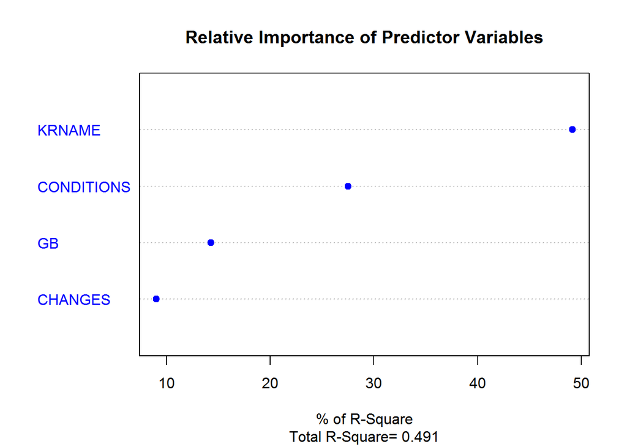

데이터 모델 lm(formula = SOLDPRICE ~ KRNAME + GB + CONDITIONS + CHANGES)  
위 모델의 adjusted R^2 은 49.1%로  
모델의 상대적 중요성은 아래와 같다.

[interactive chart not shown]

```
##              Weights
## CHANGES     9.024678
## GB         14.293727
## CONDITIONS 27.525942
## KRNAME     49.155653
```

사용자의 입장에서 가장 명백하게 선택할수 옵션들 중  
**판매가격에 가장 중요한 설명변수는 모델명, 제품의 상태, 용량, 기변구분 순서대로** 나타난다.  
최근 모델을 선택하는것은 더 좋은 제품상태, 용량, 기변구분을 선택하는 것과 비슷한 중요도로 나타난다.